# Examen parcial - Otoño 2020

Yalidt Díaz - 141394

Bruno Gonzalez - 150370

**Entrega:** Enviar la carpeta que incluya datos y codigo de solución a mas tardar el 19 de octubre antes de las 12:00pm (mediodia), por correo electrónico con el título fundamentos-parcial, un solo documento por equipo. No se aceptarán entregas extemporáneas. Será mejor entregar un examen resuelto parcialmente, que no entregar nada.

**Instrucciones:**

- Tus respuestas deben ser claras y debes explicar los resultados, incluye también tus procedimientos/código de manera ordenada, y el código comentado.
- Se evaluará la presentación de resultados (calidad de las gráficas, tablas, …), revisa la sección de visualización en las notas.
- Las sesiones del Martes 13 y Jueves 15 a las 10 am, serán espacios para resolver dudas que puedan surgir del exámen.
- No pueden compartir soluciones entre diferentes equipos, o alumnos del grupo 001 de esta misma materia.
- Al entregar este examen afirmas que el trabajo se realizó sólo con tu compañero de equipo. El material que utilizaste para apoyarte consistió de las notas en clase (pdf en canvas), el codigo fuente de las notas en el repositorio de Github, y el video disponible de la sesión de Martes 6 de Octubre.
- Al entregar estás dando tu consentimiento para que bajo sospecha y suficiente evidencia de copia se anule tu evaluación.

# Análisis exporatorio (25 %)

### 1. NBER TH

Considera la tabla de datos dada en tabla_nber_th.csv. Es la tabla de frecuencias de 4353 pilotos de la segunda guerra mundial, donde los individuos están clasificados según:

- Tipo de ocupación en 1969. SE significa self-employed.
- Resultados de estudios de aptitud de 1943 (A5 es el nivel más alto, y A1 el más bajo).
- Nivel de educación en 1969 (esta incluye años de escuela en 1943 más estudios posteriores a la guerra). E4 es el nivel más alto y E1 es el nivel más bajo.

```r
pilotos<- read.csv("./datos/tabla_nber_th.csv")
glimpse(pilotos)
```

```
## Rows: 80
## Columns: 4
## $ Ocup_group <chr> "SE - business", "SE - business", "SE - business", "SE - b…
## $ Education  <chr> "E1", "E1", "E1", "E1", "E1", "E2", "E2", "E2", "E2", "E2"…
## $ Aptitude   <chr> "A1", "A2", "A3", "A4", "A5", "A1", "A2", "A3", "A4", "A5"…
## $ Freq       <int> 42, 72, 90, 27, 8, 55, 82, 106, 48, 18, 22, 60, 85, 47, 19…
```

1. ¿Qué relación existe entre aptitud (1943) y el nivel de educación (1969)? Describe esta relación usando tablas de porcentajes y de índices (o perfiles).

```r
tabla_cruzada <- pilotos %>%
  group_by(Education, Aptitude) %>%
  summarise(Freq = sum(Freq)) %>%
  ungroup() %>%
  group_by(Education) %>%
  mutate(prop = round(100*Freq/sum(Freq),1)) %>%
  select(-Freq) %>%
  pivot_wider(names_from = Education, values_from = prop)

kable(tabla_cruzada)
```

| Aptitude | E1 | E2 | E3 | E4 |
| --- | --- | --- | --- | --- |
| A1 | 20.7 | 18.8 | 11.2 | 8.6 |
| A2 | 27.0 | 25.7 | 23.0 | 20.4 |
| A3 | 35.8 | 34.8 | 36.1 | 39.8 |
| A4 | 12.3 | 15.9 | 19.2 | 19.2 |
| A5 | 4.2 | 4.8 | 10.6 | 12.1 |

**R. La tabla de porcentajes (arriba) muestra la proporción de cada tipo de actitud para cada nivel de educación.**

```r
num_grups <- n_distinct(pilotos %>% select(Education))

tabla <-  pilotos %>%
  group_by(Education, Aptitude) %>%
  summarise(Freq = sum(Freq)) %>%
  ungroup() %>%
  group_by(Education) %>%
  mutate(prop_aptitud = 100*Freq/sum(Freq)) %>%
  group_by(Aptitude) %>%
  mutate(prop_educacion = sum(prop_aptitud)/num_grups) %>%
  mutate(perfil = round(100 * (prop_aptitud/prop_educacion-1)))

tabla_perfil <- tabla %>%
  select(Education, Aptitude, perfil, pct=prop_educacion) %>%
  pivot_wider(names_from=Education, values_from=perfil, values_fill=list(perfil=-100))

perfil <- tabla_perfil %>%
  arrange(desc(E1)) %>%
  select(-pct)

kable(perfil)
```

| Aptitude | E1 | E2 | E3 | E4 |
| --- | --- | --- | --- | --- |
| A1 | 40 | 27 | -25 | -42 |
| A2 | 13 | 7 | -4 | -15 |
| A3 | -2 | -5 | -2 | 9 |
| A4 | -26 | -5 | 15 | 15 |
| A5 | -47 | -40 | 34 | 53 |

**R. Arriba se muestra la table de perfiles.**

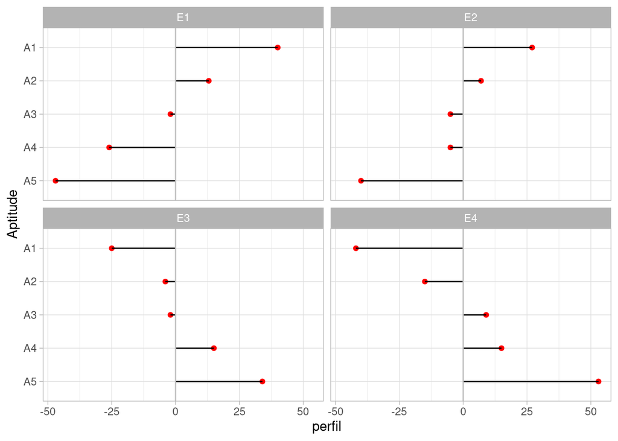

```r
tabla_graf <- tabla_perfil %>%
  ungroup %>%
  mutate(Aptitude = fct_reorder(Aptitude, E1)) %>%  #ordenamos respecto a E1
  select(-pct) %>%
  pivot_longer(cols = -Aptitude, names_to = "Educacion", values_to = "perfil")

g_perfil <- ggplot(tabla_graf,
  aes(x = Aptitude, xend = Aptitude, y = perfil, yend = 0, group = Educacion)) +
  geom_point(color="red") + geom_segment() + facet_wrap(~Educacion, nrow = 2) +
  geom_hline(yintercept = 0 , colour = "gray")+ coord_flip() + theme_light()

g_perfil
```

**R. En el caso de E1 y E2 (nivel más bajo de educación) se observa que hay una alta tasa de pilotos que tienen poco puntaje de aptitudes (aunque en la E1 esta tasa es mayor), de igual manera en estos 2 niveles de educación (E1 y E2) se obtienen altas tasas negativas de personas que hayan tenido un nivel de aptitud muy alto. Esto justamente confirma nuestra creencia inical de que las pilotos que no tienen un alto grado de Educación dificilmente tendrían un nivel alto en sus pruebas de aptitudes.**

**Por otro lado en los niveles de Educación E3 y E4 la relación se voltea es decir observamos altas tasas de personas que tienen tienen niveles de aptitudes altos (A5 y A4), y por el contrario pocos perfiles de pilotos en esos niveles de educación con un resultado de aptitudes bajas.**

2. Describe la relación entre nivel de educación y ocupación ¿Qué concluyes de esta relación? ¿Cuáles dirías que son ocupaciones asociadas a educación alta y cuáles a educación baja?

```r
tabla_ocupacion <- pilotos %>%
  group_by(Ocup_group, Education) %>%
  summarise(Freq = sum(Freq)) %>%
  group_by(Ocup_group) %>%
  mutate(Freq_ocup = round(100*Freq/sum(Freq))) %>%
  group_by(Education) %>%
  mutate(Freq_edu = round(100*Freq/sum(Freq)))
```

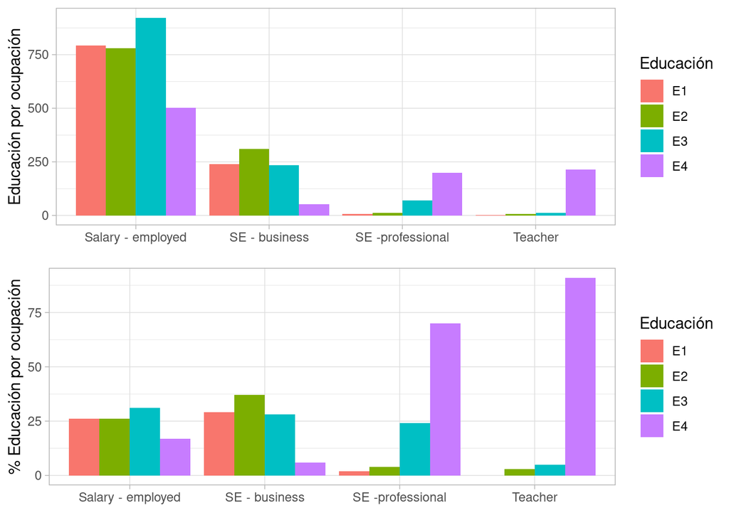

```r
p1 <- tabla_ocupacion %>%
  ggplot() +
  geom_col(aes(x=Ocup_group, y=Freq, fill=Education), position = "dodge") +
  labs(x=element_blank(), y="Educación por ocupación") +
  scale_fill_discrete(name="Educación") +
  theme_light()

p2 <- tabla_ocupacion %>%
  ggplot() +
  geom_col(aes(x=Ocup_group, y=Freq_ocup, fill=Education), position = "dodge") +
  labs(x=element_blank(), y="% Educación por ocupación") +
  scale_fill_discrete(name="Educación") +
  theme_light()

grid.arrange(p1,p2)
```

**R. De estas primeras gráficas agrupadas por ocupación se observa que en las ocupaciones de “Salary-employed” y “Se-business” hay más variedad de grados de educación y que el nivel de educación que menos tiene representación en estas dos ocuapciones es E4 (nivel de mayor grado). Por otra parte en las ocupaciones de “SE-profesional” y “Teacher” hay gran disparidad en los niveles de educación, es decir muy pocas personas tienen bajos niveles de educación y las educaciones que tienen mayor participación en estas ocupaciones son E3 y E4 (siendo E4 la que representa mayor proporción)**

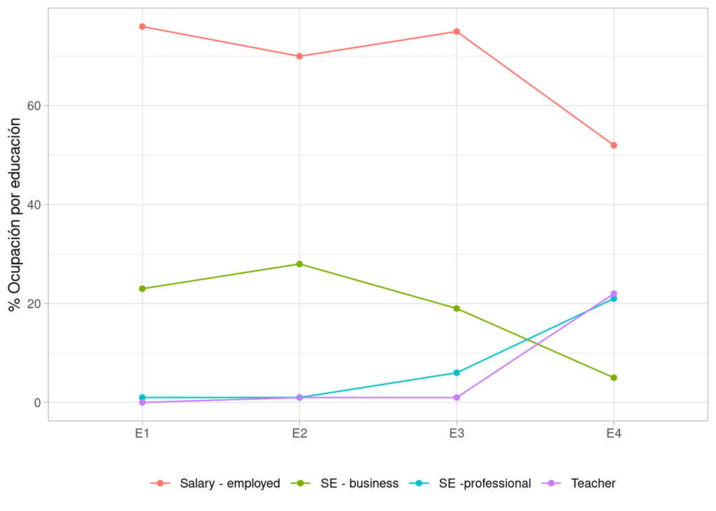

```r
tabla_ocupacion %>%
  ggplot(aes(x=Education, y = Freq_edu, col = Ocup_group, group = Ocup_group)) +
  geom_point() +
  geom_line() +
  labs(x=element_blank(), y="% Ocupación por educación") +
  scale_color_discrete(name=element_blank()) +
  theme_light() +
  theme(legend.position = "bottom")
```

**R. En esta 2da gráfica se concluye que las ocupaciones que en general tienen un menor proporcion de educación son “SE-Profesional” y “Teacher”, aunque tienen mayor educación en E4. De igual manera en general las ocupaciones que tienen en promedio mayor participación son “SE-business” y “Salary-employed”, pero justamente tienen menor proporción de eduación alta (E4)**

# Mini-proyecto (75 % + 5%)

Utilizaremos los datos de un experimento de modificación del tiempo *(weather)* en el cual se investigó el efecto de yoduro de plata (IAg) para atenuar tormentas eléctricas [Baughman et al 1976](https://www.jstor.org/stable/26177578?seq=1#metadata_info_tab_contents)

Los datos se generaron seleccionando al azar tormentas candidato en donde se incorporó el aerosol *(seeding)* de manera aleatoria. Es decir, una vez seleccionando una posible tormenta, se decidió al azar si rociar o no las nubes con el aerosol mencionado.

Los resultados se pueden cargar de la siguiente tabla. Las columnas son la fecha en la que ocurrió la tormenta, el número de truenos que hicieron contacto con tierra, y el indicador si la tormenta fue tratada con aerosoles o no. Previo a la recolección de datos se espera que el yoduro de plata disminuya el número de truenos que impacten la tierra.

```r
#Lectura de los datos
truenos <- read_csv('./datos/tormentas.csv')
truenos
```

```
## # A tibble: 23 x 3
##    fecha      conteos aerosol
##    <date>       <dbl> <chr>
##  1 1965-08-19       0 No
##  2 1966-07-15       2 Si
##  3 1965-07-21       4 Si
##  4 1966-07-14       9 Si
##  5 1966-08-29      10 Si
##  6 1966-08-04      10 No
##  7 1966-07-14      12 Si
##  8 1966-07-14      16 Si
##  9 1965-07-29      18 Si
## 10 1966-09-07      20 No
## # … with 13 more rows
```

## Análisis exploratorio y pruebas de hipótesis

1. Ahora haremos un breve EDA para determinar ciertos supuestos para aplicar las técnicas que hemos visto en clase. Haz resumenes númericos del número de truenos reportados.

```r
truenos %>% summary()
```

```
##      fecha               conteos         aerosol
##  Min.   :1965-07-02   Min.   :  0.00   Length:23
##  1st Qu.:1965-07-25   1st Qu.: 11.00   Class :character
##  Median :1966-07-12   Median : 26.00   Mode  :character
##  Mean   :1966-03-06   Mean   : 43.26
##  3rd Qu.:1966-07-25   3rd Qu.: 47.00
##  Max.   :1967-07-03   Max.   :358.00
```

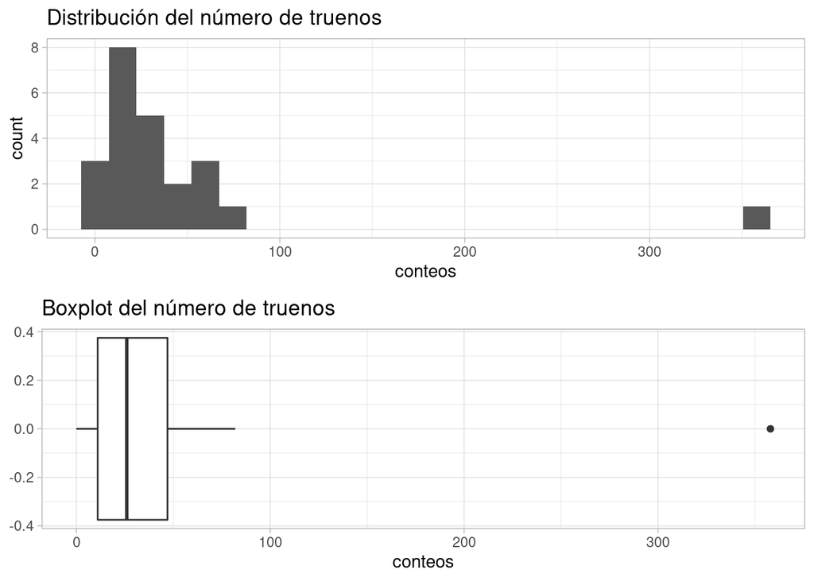

```r
g1 <- ggplot(truenos, aes(conteos)) +
  geom_histogram(bins = 25) +
  ggtitle("Distribución del número de truenos") +
  theme_light()

g2 <- ggplot(truenos, aes(conteos)) +
  geom_boxplot() +
  ggtitle("Boxplot del número de truenos") +
  theme_light()

grid.arrange(g1, g2)
```

2. Qué observaciones puedes hacer de este breve resumen? (Considera que la variable de interés son los conteos de truenos)

**R. Lo primero que salta de este análisis es que hay datos bastante atípicos de 358(justamente es el valor máximo que toma esta variable), lo cual nos hace pensar si esta información fue capturada correctamente o si realmente se obtuvo ese valor en esa tormenta electrica. Aunado a esto, dado que esos outliers son muy elevados altera la media de los datos por su ponderación.**

**Por último en el diagrama de caja y brazos, sin tomar en cuenta los datos atípicos, se podría decir que los datos son casi simétricos respecto a la media, aunque el brazo esta más alargado del lado derecho.**

3. Ahora trataremos de validar un supuesto clásico, el supuesto de normalidad. Auxiliate de herramientas gráficas para explorar este supuesto y determinar si es razonable para nuestro conjunto de datos.

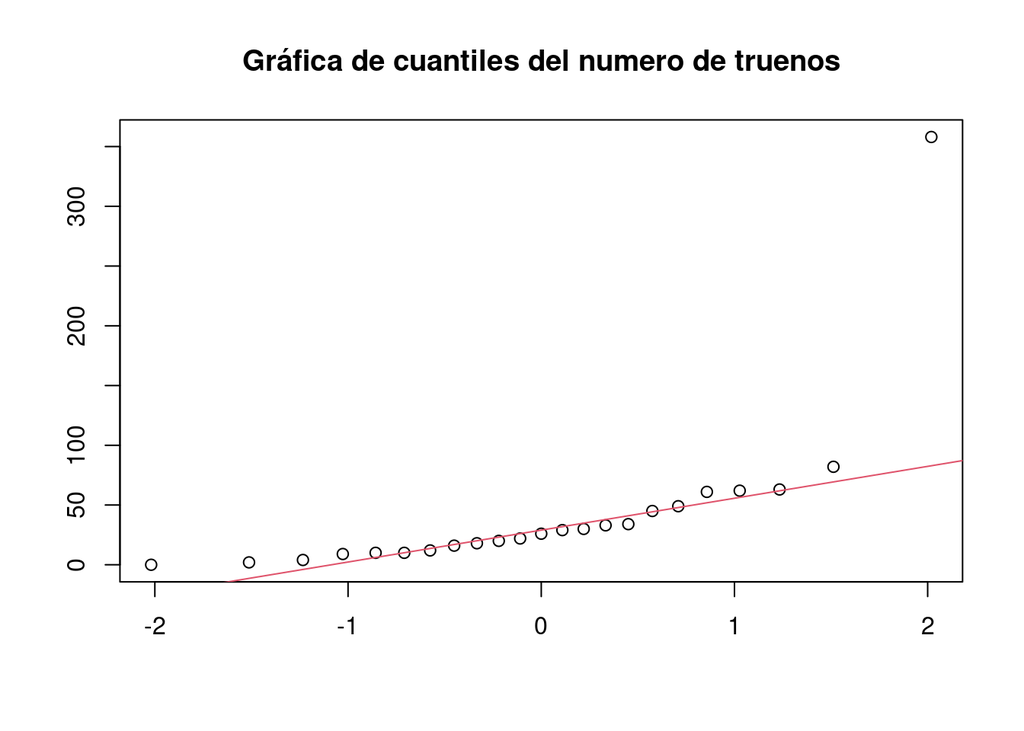

```r
qqnorm(truenos$conteos,
       main="Gráfica de cuantiles del numero de truenos",
       xlab="", ylab="")
qqline(truenos$conteos, col=2)
```

**Probablemente si utilizaramos alguna otra herramienta numérica que nos ayude a determinar si se distribuye normalmente se podría cambiar de opinión dependiendo que tan conservadores seamos**

Posiblemente estén tentados a descartar los valores atípicos. Claramente tenemos un problema. Si quisiéramos hacer una prueba de hipótesis por medio de diferencias en media, dicho valor atípico sesgaría nuestra distribución de referencia. Y el efecto sería catastrófico, valores grandes de nuestro estimador de prueba se verían como datos usuales bajo la distribución de referencias.

Una alternativa para estos casos, que no vimos en clase, es hacer un prueba de diferencia en suma de órdenes *(sum of ranks).* Para esto ordenamos los datos por la variable `conteos` y asignamos una variable `orden` que asigna el lugar que dicho registro recibe.

```r
truenos <- truenos %>%
  arrange(conteos) %>%
  mutate(orden = min_rank(conteos))

truenos
```

```
## # A tibble: 23 x 4
##    fecha      conteos aerosol orden
##    <date>       <dbl> <chr>   <int>
##  1 1965-08-19       0 No          1
##  2 1966-07-15       2 Si          2
##  3 1965-07-21       4 Si          3
##  4 1966-07-14       9 Si          4
##  5 1966-08-29      10 Si          5
##  6 1966-08-04      10 No          5
##  7 1966-07-14      12 Si          7
##  8 1966-07-14      16 Si          8
##  9 1965-07-29      18 Si          9
## 10 1966-09-07      20 No         10
## # … with 13 more rows
```

La idea es sencilla, si un grupo tiende a tener menores observaciones *la suma de sus órdenes* será menor que la suma de los órdenes del otro grupo. La diferencia de la suma de órdenes será nuestro estadístico de prueba. Y podremos comparar el observado con respecto a la distribución de referencia.

4. Escribe el código adecuado para nuestro estadístico de prueba: la diferencia de la suma de órdenes.

```r
diferencia_observada <- truenos %>%
  group_by(aerosol) %>%
  summarise(suma_ordenes= sum(orden), .groups = 'drop') %>%
  pivot_wider(names_from=aerosol, values_from = suma_ordenes) %>%
  mutate(diferencia= No-Si)

kable(diferencia_observada)
```

| No | Si | diferencia |
| --- | --- | --- |
| 167 | 108 | 59 |

**R. Esta primera diferencia observada nos estaría indicando que las tormentas sometidas al aerosol tienen un menor número de truenos**

5. La distribución de referencia implica todas las asignaciones al azar de la etiqueta que marca si la tormenta fue modificada artificialmente con aerosol. ¿Cuántas posibilidades existen para dicha distribución?

```r
permutacion = function(n, x) {

### Función que calcula el total de permutaciones de un conjunto de datos
# Inputs:
# n : escalar, Numero de de renglones en el dataset (en este caso órdenes)
# x : escalar, Valores posible de la variable que se desea escoger
# Outputs:
# permutacion : escalar, que indica el número de permutaciones posibles

  factorial(n) / factorial(n-x) / factorial(x)
}
permutacion(23,11)
```

```
## [1] 1352078
```

**R. El total de posibilidades que se podrían obtener serían 1352078, porque hay 23 órdenes, las cuales se dividen en 12 (o 11) posibles valores Si (o No). Esta es la combinación de 12 tormentas sometidas con aerosol en 23 días**

6. Por suerte, ya no estamos en los 70’s y podemos auxiliarnos de simulación para construir la distribución de permutaciones. Genera las permutaciones correspondientes por medio de simulación. Alrededor de $10^4$ serán mas que suficientes.

```r
#Cálculo de las simulaciones
set.seed(4020)
permutaciones <- lineup(null_permute("aerosol"),
                        truenos, n = 10000)
```

```
## decrypt("MzAP XDuD 3b KT03u3Tb RQwR")
```

7. Calcula el estadístico de prueba para las permutaciones y grafica un histograma donde muestres el estadistico de prueba observado.

```r
#Cálculo de la diferencias en la simulación
distribucion_ref <- permutaciones %>%
  group_by(.sample,aerosol) %>%
  summarise(suma_ordenes=sum(orden), .groups = 'drop') %>%
  pivot_wider(names_from = aerosol, values_from = suma_ordenes) %>%
  mutate(dif=(No-Si))
```

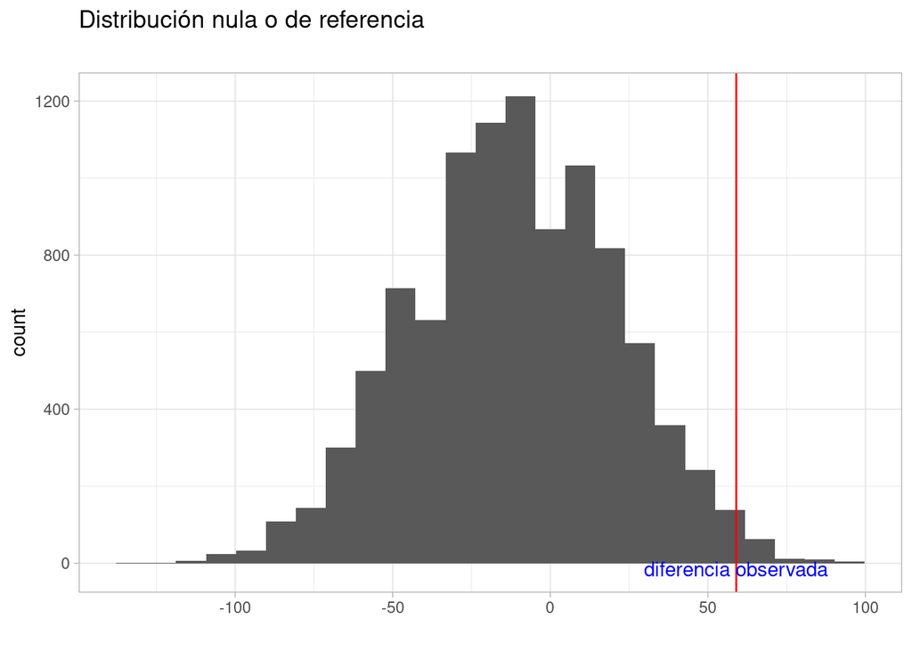

```r
ggplot(distribucion_ref, aes(x = dif)) +
  geom_histogram(binwidth = 9.5) + xlab("") + labs(subtitle = " ") +
  geom_vline(xintercept = diferencia_observada$diferencia[1], colour = "red") +
  annotate("text",
           x = diferencia_observada$diferencia[1],
           y = -15 ,
           label = "diferencia observada",
           colour = "blue") +
  ggtitle("Distribución nula o de referencia ") +
  theme_light()
```

8. Calcula el *valor-p* de la hipótesis nula y escribe tu reporte sobre dicha prueba de hipótesis.

```r
dist_perm <- ecdf(distribucion_ref$dif)
#Nuestra prueba de hipótesis es de 2 colas porque H_0 : no hay diferencias y H_1 : si hay diferencia
2 * min(dist_perm(diferencia_observada$diferencia[1]), (1 - dist_perm(diferencia_observada$diferencia[1])))
```

```
## [1] 0.0214
```

**R. Nuestra Hipótesis Nula H_0 era que no había diferencias entre las tormentas que tuvieron el aerosol y las que no (prueba de 2 colas):**

$$H_0 : \sum({ordenes_{S}}-{ordenes_{N}})=0$$
$$H_1 : \sum({ordenes_{S}}-{ordenes_{N}}) \neq 0$$

**Dado que el valor-p obtenido fue de .0214, si tomaramos un $\alpha = .05$ nuestro valor es aún mas pequeño que este $\alpha$, con lo cual estaríamos rechazando $H_0$ y nos quedaríamos con $H_1$. Es decir existe evidencia de que hay diferencia entre los grupos de órdenes de tormentas cuando se pone el aerosol**

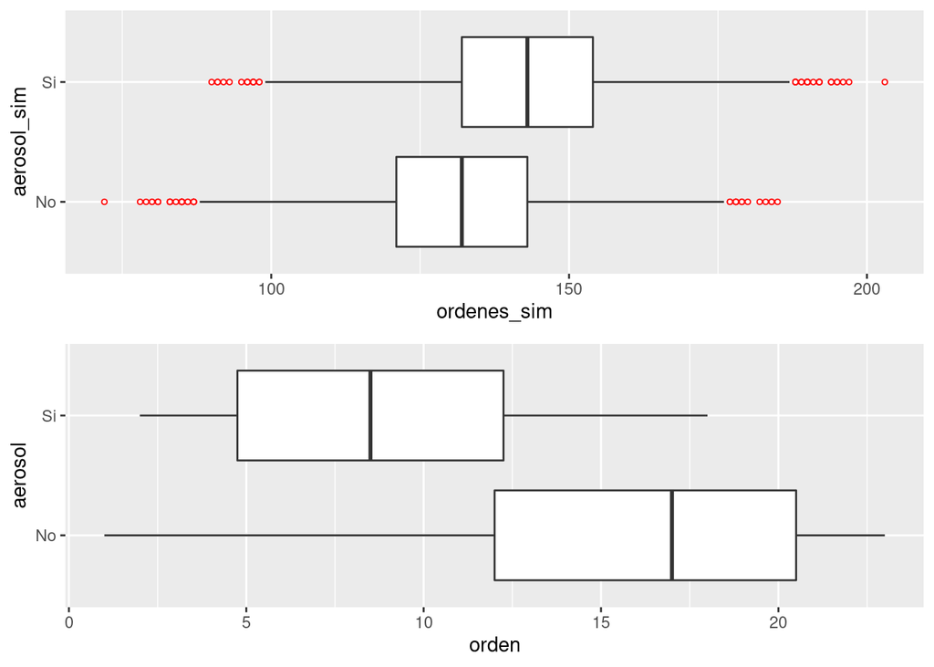

```r
aux <- distribucion_ref %>% gather(aerosol_sim , ordenes_sim, No:Si)

g1 <- ggplot(aux, aes(x = aerosol_sim, y = ordenes_sim)) +
  geom_boxplot(outlier.size = 1, outlier.colour = "red", outlier.shape = 21) +
  coord_flip()

g2 <- ggplot(truenos, aes(x = aerosol, y = orden)) +
  geom_boxplot(outlier.size = 1, outlier.colour = "red", outlier.shape = 21) +
  coord_flip()

grid.arrange(g1, g2)
```

**R. Realizamos 2 gráficas de caja y brazos para ver como se comportaban los datos originales y los simulados, en ambos casos el número de ordenes se ve que cambia dependiendo si se aplica o no el aerosol. lo único curioso es que en las simulaciones resultó que las tormentas que no reciben el aerosol son las que tienen menor rank, sinembargo claramente se observa que hay diferencia entre los grupos

El cambio en el menor numero de rank responde justo al incluir alietoriedad, se difumina la diferencia, siendo consistente con la prueba de hipótesis de arriba**

**5% extra.** A continuación mostramos lo que una prueba vista en cursos clásicos de estadística arrojaría. ¿Puedes interpretarla?

```r
wilcox.test(truenos$conteos~truenos$aerosol,
            alternative="greater")
```

```
##
##  Wilcoxon rank sum test with continuity correction
##
## data:  truenos$conteos by truenos$aerosol
## W = 101.5, p-value = 0.0156
## alternative hypothesis: true location shift is greater than 0
```

**R. Esta prueba justamente calcula el valor-p y resuelve la prueba de hipótesis sobre las órdenes que son el número de rank que tiene cada tormeta dependiendo del número de truenos que recibió. Nos indica un valor-p de .0156 porque esta considerando una prueba de hipótesis de 1 sola cola (justo por eso en el parámetro de la función de indica : alternative = “greater”), y este valor p es pequeño (de .0156), con lo cual al final nos indica la $H_1 > 0$ (la hipótesis alternativa es mayor a cero). De esta manera indica que la diferencia entre la suma de los rank(órdenes) es mayor a 0, por lo que si hay evidencia en contra de $H_0$.**

```r
wilcox.test(truenos$conteos~truenos$aerosol,
            alternative="two.sided")
```

```
##
##  Wilcoxon rank sum test with continuity correction
##
## data:  truenos$conteos by truenos$aerosol
## W = 101.5, p-value = 0.03119
## alternative hypothesis: true location shift is not equal to 0
```

**R. Si realizaramos la prueba Wilcox con una prueba de 2 colas vemos que justamente el valor-p se mutiplica por 2 y es el doble del caso anterior**

# Distribución *bootstrap* para estimadores con cocientes

Supongamos ahora que para efectos del análisis la dispersión de los datos de las tormentas se pueden caracterizar por medio de la estadística de escala en L *(L-scale)* [Hoskin, 1990](https://www.jstor.org/stable/2345653?seq=1#metadata_info_tab_contents),
$$\lambda_2 = \frac{2}{n (n -1)} \sum_{i = 1}^{n-1} \sum_{j = i + 1}^n |x_i - x_j|,$$
donde $\lambda_2$ caracteriza la mitad de la distancia promedio entre todos los posibles pares en una muestra de tamaño $n.$ Para un conjunto de datos muy concentrado el valor de $\lambda_2$ será muy pequeño, mientras que para un conjunto de datos mas dispersos éste será grande.

Compararemos el valor de $\lambda_2$ para las tormentas tratadas con aerosoles y las tormentas sin el tratamiento. Para esto compararemos el cociente
$$\theta_L = \frac{\lambda_2^{S}}{\lambda_2^{N}},$$
donde $\lambda_2^{S}$ denota la estadística $L$ calculada para las tormentas con aerosol, y $\lambda_2^{N}$ para las tormentas sin aerosol.

Si siguiéramos el camino de prueba de hipótesis consideraríamos una hipótesis nula donde $\theta_L = 1$.

9. Escribe la función que calcule la estadística $\lambda_2$. Para esto sugerimos le heches un ojo a la función `dist`. Una vez que tengas esa función utilizala para realizar simulaciones como en los puntos anteriores y puedas explorar la distribución de referencia. ¿Qué observas de la distribución resultante?

```r
lambda <- function(df, val){

### Función que calcula el parámetro Lambda dado un conjunto de muestras pareadas
# Inputs :
# df - df que contiene las muestras
# val - Parámetro que indica para que grupo se desea calcula lambda
# Outputs :
# lambda - parámetro que resulta de la siguiente fórmula una ves calculada la suma de las distancias : \lambda_2 = \frac{2}{n (n -1)} \sum_{i = 1}^{n-1} \sum_{j = i + 1}^n |x_i - x_j|

  x <- df %>% filter(aerosol == val) %>% select(conteos)
  n <- nrow(x)
  d <- sum(dist(x))
  lambda <- 2*d/(n*(n-1))
  return(lambda)
}

t <- lambda(truenos,"Si")/lambda(truenos,"No")
t
```

```
## [1] 0.1883065
```

**R. El valor de theta para los datos es de $0.19$, indicando una mayor disperción en las tormentas que no fueron tratadas con aerosol.**

```r
set.seed(4020)
ls <- permutaciones %>%
  group_by(.sample) %>%
  nest() %>%
  pull(data) %>%
  map_dbl(lambda, val="Si")

ln <- permutaciones %>%
  group_by(.sample) %>%
  nest() %>%
  pull(data) %>%
  map_dbl(lambda, val="No")

theta <- ls/ln
```

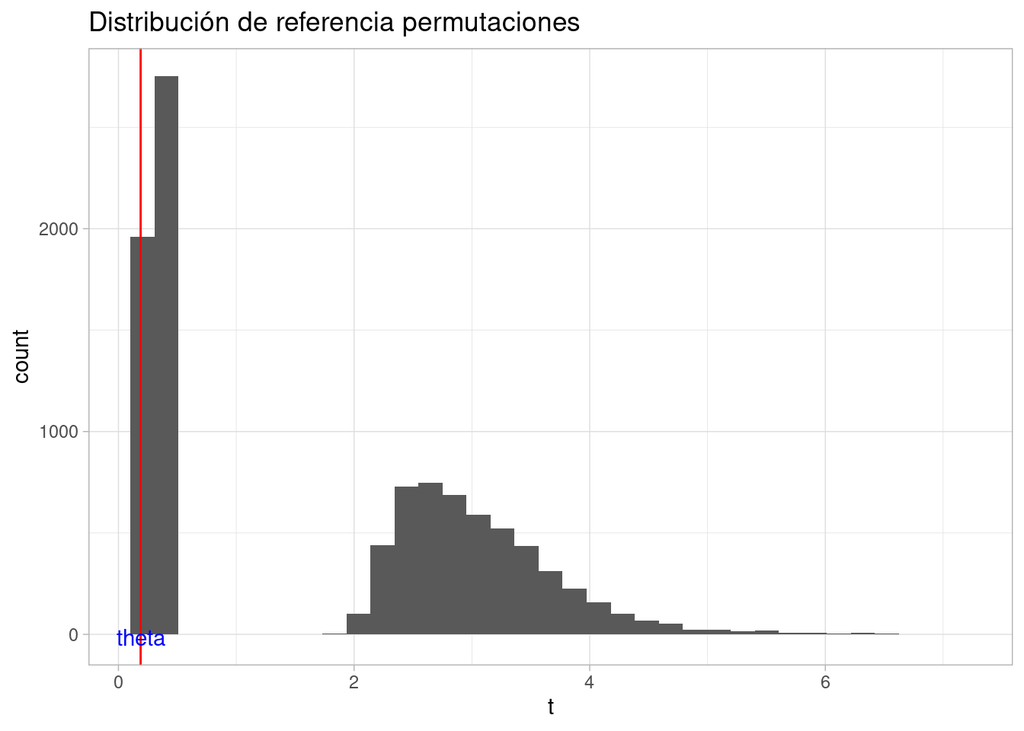

```r
tibble(t=theta) %>%
  ggplot(aes(x=t)) +
  geom_histogram(bins = 35) +
  geom_vline(xintercept = t, colour = "red") +
  ggtitle("Distribución de referencia permutaciones") +
    annotate("text",
           x = t,
           y = -15 ,
           label = "theta",
           colour = "blue") +
  theme_light()
```

**R. En este histograma la distribución de referencia fue sobre conteos (que es el número de truenos que tocan la tierra) y nos damos cuenta que hay 2 grupos o clusters completamente separados. Es decir vemos 2 distribuciones de cada grupo de tormentas (los que reciben el aerosol y los que no), y se observa que con permutaciones el primer grupo tiene una distribución muy picuda con thetas menores a 1, por otro lado la 2da distribución que se observa tiene thetas entre 2 y 6 aproximadamente (con sesgo a la derecha)**

10. Cuál es tu conjetura de que la distribución de referencia tenga esa forma?

**R. Que los grupos de tormentas estan separados y tienen distribuciones distintas, se ven claramente 2 modas en la gráfica del histograma obtenido. Y como primer creencia se tendría que las thetas pequeñas son aquellas donde hay mayor dispersión en las tormentas sin el aerosol, por el contrario en el intervalo de thetas (2 - 6) las tormetas que tienen mayor dispersión son las que se someten al aerosol.**

En este caso hacer una prueba de hipótesis para la estadística de la $L-$dispersión por medio de permutaciones no es la mejor estrategia. Esto es por que la hipótesis nula alberga el supuesto de que **todos** los aspectos de la distribución de truenos que golpean la tierra son los mismos tanto para las tormentas modificadas por aerosoles y las que no lo son. En este caso, quisiéramos ser mas laxos y permitir algunas propiedades diferentes entre las dos distribuciones.

Usaremos el método de *bootstrap* para calcular la distribución de remuestreo de nuestra estadística observada. Como sabemos, el método de bootstrap nos informa de la dispersión de nuestra estadística de interés, que en este caso es la $L-$dispersión.

11. Escribe el código necesario para implementar un bootstrap no paramétrico. Recuerda que el remuestreo debe de respetar el proceso generador de datos. *Pista:* Sugerimos utilizar la libreria de `rsample`, considera que tu función de estimación debe de regresar una tabla, `tibble`, con dos columnas `estimate` y `term`, donde se registra el valor estimado y nombre de tu estadistica. Por supuesto puedes utilizar otras funciones.

**R.**

```r
funcion_bootstrap <- function(df){

### Función que calcula el las muestras bootstrap y sobre esas muestras se calcula el estimador theta que es el cociente de lambdas de cada grupo
# Inputs :
# df - df que contiene las muestras
# Outputs :
# lambda - parámetro que theta que se obtiene de la siguiente expresion :
#\theta_L = \frac{\lambda_2^{S}}{\lambda_2^{N}}

  m <- sample_frac(df, replace = TRUE)
  theta <- lambda(m,"Si")/lambda(m,"No")
  return(theta)
}
```

12. Reporta la dispersión de tu estimador en forma de intervalos con el método más adecuado de los vistos en clase.

```r
#Librería rsample
library(rsample)

estimador_boot <- function(split){
### Función que calcula el estimador theta sobre un el dataframe de truenos
# Inputs :
# split - permite dividir el dataframe en grupos con respecto al grupo (aerosol)
# Outputs :
# dataframe - regresa un dataframe con la columna estimate (la que calcula theta) y con la columna
# term (que es el nombre del estimador)
  truenos <- analysis(split)   # ¿Si va truenos o una muestra?

  truenos %>% summarise(estimate = funcion_bootstrap(.)) %>% mutate(term = "theta")

}

thetas_boot <- bootstraps(truenos, strata = aerosol, 5000) %>%
  mutate(boot_e=map(splits, estimador_boot))
```

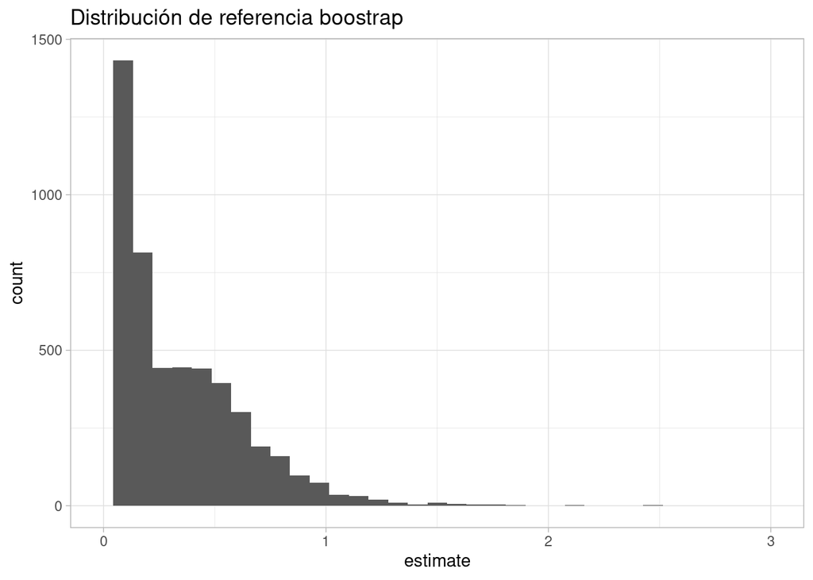

```r
thetas_boot %>%
  select(-splits) %>%
  unnest() %>%
  select(term, estimate) %>%
  ggplot(aes(x=estimate)) +
  geom_histogram(bins = 35) +
  xlim(0,3) +
  ggtitle("Distribución de referencia boostrap") +
  theme_light()
```

```r
thetas_boot %>% int_pctl(boot_e, alpha= .05)
```

```
## # A tibble: 1 x 6
##   term  .lower .estimate .upper .alpha .method
##   <chr>  <dbl>     <dbl>  <dbl>  <dbl> <chr>
## 1 theta 0.0517     0.355   1.03   0.05 percentile
```

13. Dado el estimador y los intervalos calculados arriba, escribe un breve resumen.

**Donde las $\lambda$s representan 2 cosas (dispersión y tambien de alguna manera considera el rank), entonces se puede concluir que para que este cociente sea un número pequeño puede ser por lo siguiente : numerador ($\lambda_2^{S}$) tiene un valor menor que el denominador ($\lambda_2^{N}$), en otras palabras $\lambda_2^{S}$ < $\lambda_2^{N}$, por lo que el grupo de tormetas que se somete a la aplicación del aerosol tiene menor dispersión que las que no tienen el aerosol. Esta conclusión es la que vemos en los histogramas de arriba (principalmente el de permutaciones), donde se ve que ambos grupos tienen distribuciones diferentes y la de las tormentas que tienen aplicado el aerosol esta bastante concentrada, casi no hay varianza, por el contrario las tormetas que no tienen aplicado este químico representan una distribución más aplanada con mayor varianza**